# Distributions and Testing

T. Manke

7 Dec 2016

# Pseudo-Random Sampling (with replacement)

```r
coins=c(0,1)  # ~ (tail, head="success")

sample(coins,10,replace=TRUE)   # throw coins 10 times
```

```
##  [1] 0 1 1 0 1 1 1 1 1 1
```

```r
sample(coins,10,replace=TRUE)   # and again (pseudorandom numbers)
```

```
##  [1] 0 1 0 0 1 0 1 0 0 0
```

```r
sample(coins,10,replace=TRUE)   # and again (pseudorandom numbers)
```

```
##  [1] 1 0 1 0 1 0 0 1 1 1
```

```r
# random number generators need a seed variable
# usually this is implicitly set by some time stamp and process ID: --> ?set.seed
# here we set it explicitly based on some fixed integer (123 is arbit)
set.seed(123)     # 123 is arbitrary
sample(coins,10,replace=TRUE)
```

```
##  [1] 0 1 0 1 1 0 1 1 1 0
```

```r
set.seed(123)    # use _identical_ seed
sample(coins,10,replace=TRUE)   # deterministic result
```

```
##  [1] 0 1 0 1 1 0 1 1 1 0
```

# Fair and Unfair coins

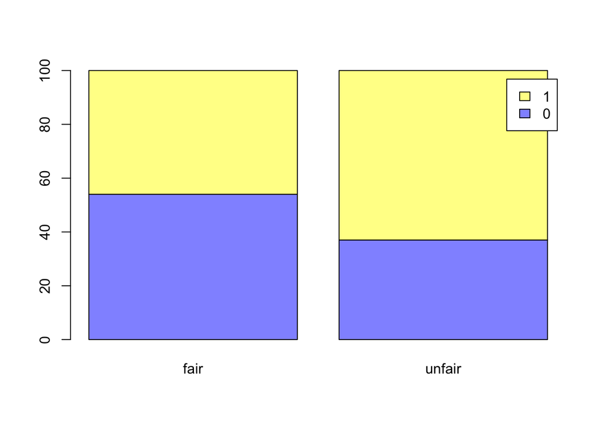

```r
N=100         # number of throws
# two coins, each thrown N times
fair=sample(coins,N,replace=TRUE)                      # unbiased sampling (fair coin)
unfair=sample(coins,N,replace=TRUE, prob=c(0.4,0.6))   # biased sampling

# generate table of counts
counts=cbind(fair=table(fair),unfair=table(unfair))

# define some (non-default) colors for barplot
myblue=rgb(0,0,1,0.5)
myyell=rgb(1,1,0,0.5)
barplot(counts, col=c(myblue,myyell), legend.text=TRUE)
```

Based on such sampling experiments (Bernoulli), how can we test if coin was fair (p=0.5) or unfair (p>0.5)?

## 1. Define a “test statistics”

Number of heads (“successes”)

```r
fair_head=sum(fair)
unfair_head=sum(unfair)
cat("fair=", fair_head, "unfair=", unfair_head)
```

```
## fair= 46 unfair= 63
```

## 2. Define Fair Expectation

Expected distribution of test-statistics. For $N$ coins (Bernoulli variables), the sum of heads ($k$) follows the *Binomial Density distribution*:

$B(k | N,p) = {N \choose k} p^k(1-p)^{(N-k)}$

Null hypothesis (fair coin) $H_0: p=0.5$

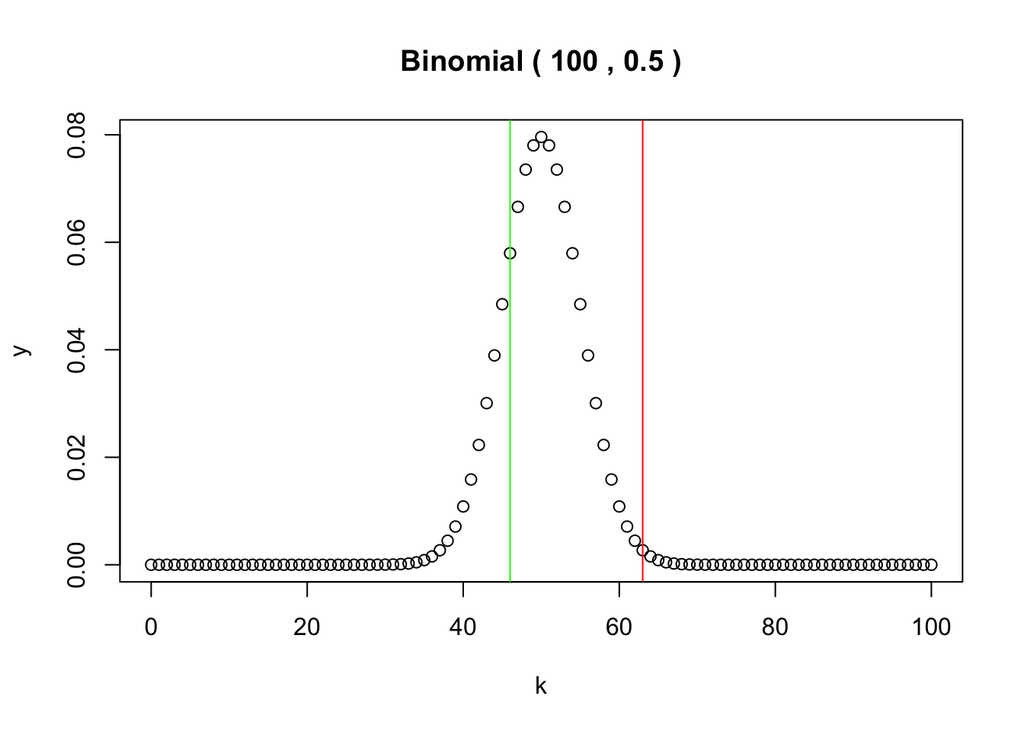

```r
k=0:100
y=dbinom(k, size=N, prob=0.5)
title=paste("Binomial (",N,",",0.5,")")
plot(k,y, main=title)
abline(v=fair_head, col="green") # plot observation from fair coin
abline(v=unfair_head, col="red") # plot observation from unfair coin
```

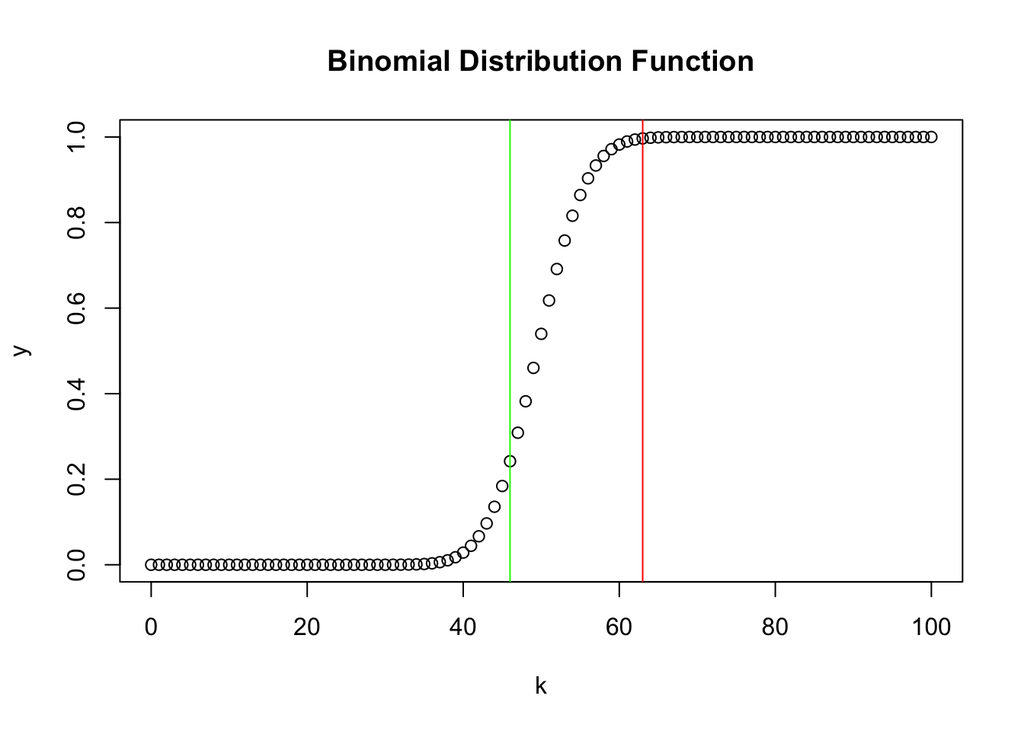

```r
# same for cummulative distribution function
y=pbinom(k,size=N,prob=0.5)
plot(k,y, main="Binomial Distribution Function")
abline(v=fair_head, col="green") # plot observation from fair coin
abline(v=unfair_head, col="red") # plot observation from unfair coin
```

## 3. Evaluate surprise: Fisher’s P-value

Assuming fair distribution ($H_0$), calculate probability for observing a given number of heads (or larger) = area under upper tail

```r
pf=pbinom(fair_head-1,   size=100, prob=0.5, lower.tail=FALSE)   # why "fair_head - 1" ?
pu=pbinom(unfair_head-1, size=100, prob=0.5, lower.tail=FALSE)
cat("p(fair)=", pf, "p(unfair)=", pu)
```

```
## p(fair)= 0.8158992 p(unfair)= 0.006016488
```

**Task**: Report those p-values to the class.

The same can be obtained by a binomial test. Notice different choices of “more extreme”

```r
# as above: is the number of heads greater than expected by chance
bt=binom.test(unfair_head, 100, 0.5, alternative="greater")
bt$p.value
```

```
## [1] 0.006016488
```

```r
# two.sided: is the number of heads higher or lower than expected by chance
bt=binom.test(unfair_head, 100, 0.5, alternative="two.sided")
bt$p.value  # here: = 2 x one-sided (because of symmetry for prob=0.5)
```

```
## [1] 0.01203298
```

```r
# binom.test() returns more information
# e.g. 95% confidence interval for success probability
bt$conf.int  # does the confidence interval include p=0.5?
```

```
## [1] 0.5276484 0.7244334
## attr(,"conf.level")
## [1] 0.95
```

## 4. P-value Simulation

Goal: sample larger number of p-values

```r
NR=200
#1. generate number of heads from NR experiments
H0 = rbinom(NR, size=N, prob=0.5)

#2. convert vector H0 to vector of p-values
p0 = pbinom(H0-1, size=N, prob=0.5, lower.tail=FALSE)

head(sort(p0)) # some p-values are small
```

```
## [1] 0.001758821 0.003318560 0.010489368 0.010489368 0.028443967 0.028443967
```

```r
# discretization of surprisal (acceptance/rejection). R. Fisher would not have done this.
table(p0 < 0.05)
```

```
##
## FALSE  TRUE
##   190    10
```

**Lessons**:

- P-values are random variables
- fair coins can produce small p-values (unfair coins can produce large p-values)
- Fisher significance testing relies on single hypothesis: $H_0$
- test-statistics $\to$ null distribution $\to$ p-value
- different ways to define “more extreme” events (e.g. one- or two-tailed)
- P-value is not everything; report confidence interval

# Neyman-Pearson Procedure

Formalize rejection and acceptance procedure. Introduce the *alternative hypothesis*. $N$ throws of a biased coin will also generate a certain number of heads. Repeating this experiment many times (NR) will generate a distribution of the number of heads:

```r
Ha=rbinom(NR, size=N, prob=0.6)
```

Goal: Based on $H_0$ and $H_a$, define a threshold to reject one or the other hypothesis.

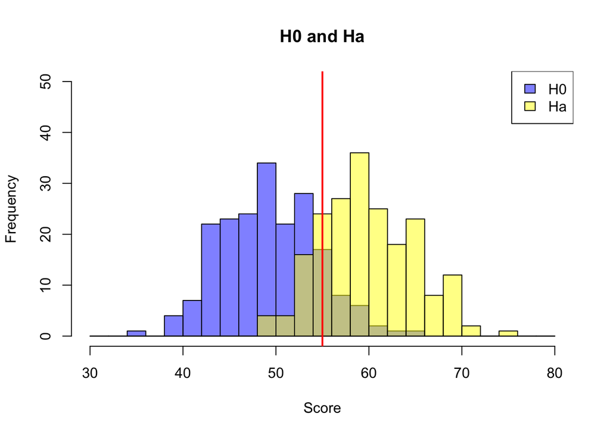

```r
# set up some graphics parameters for convenience
br=seq(30,80,2)

# plot histograms
hist(H0, breaks=br, col= myblue, xlim=c(30,80), ylim=c(0,50), xlab= "Score", main="H0 and Ha")
hist(Ha, breaks=br, col= myyell, add=TRUE)
legend("topright", c("H0","Ha"), fill=c(myblue,myyell))

# illustrate some (arbitrary) threshold
thresh=55
abline(v=thresh,lwd=2,col="red")
```

## Contigency table (Confusion matrix) for given threshold

Each decision is a compromise between false positives and false negatives

```r
d1 = data.frame(test=H0, coin="H0")
d2 = data.frame(test=Ha, coin="Ha")
df = rbind(d1,d2)

contigencyTable = function(df,thresh) {

  df$test=ifelse(df$test<thresh, "H0", "Ha")
  C=table(df)

  # Type1 = FPR = FP/[FP+TN] = 1 - Specificity = Pr (reject|H0)
  Type1=C["Ha", "H0"] / (C["Ha", "H0"] + C["H0", "H0"])

  # Type2 = FNR = FN/[TP+FN] = 1 - Sensitivity = 1 - power = 1 - recall = Pr(accept|Ha)
  Type2=C["H0", "Ha"] / (C["H0", "Ha"] + C["Ha", "Ha"])

  # PPV = TP/[TP + FP] = 1 - FDR = Pr(Ha|reject)
  PPV=C["Ha", "Ha"] / (C["Ha", "Ha"] + C["Ha", "H0"])

  # FDR = FP/[TP + FP] = 1 - PPV = Pr(H0|reject)
  FDR=C["Ha", "H0"] / (C["Ha", "Ha"] + C["Ha", "H0"])

  show(C)
  cat("thresh=",thresh,"Type1=",Type1,"Type2=",Type2,"power=",1-Type2,"FDR=",FDR)
}

contigencyTable(df,thresh=55)
```

```
##     coin
## test  H0  Ha
##   H0 165  24
##   Ha  35 176
## thresh= 55 Type1= 0.175 Type2= 0.12 power= 0.88 FDR= 0.1658768
```

```r
contigencyTable(df,thresh=65)
```

```
##     coin
## test  H0  Ha
##   H0 199 154
##   Ha   1  46
## thresh= 65 Type1= 0.005 Type2= 0.77 power= 0.23 FDR= 0.0212766
```

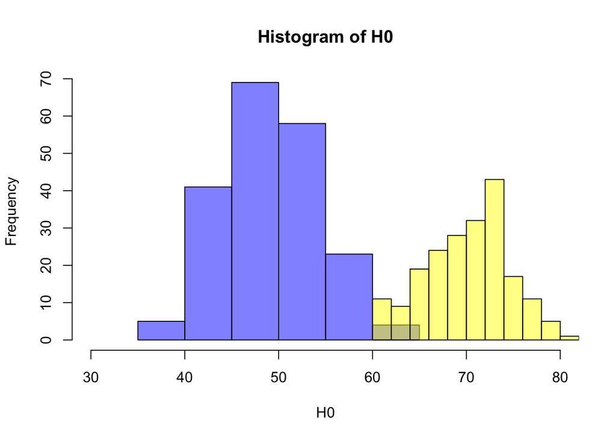

```r
# Increasing the bias (effect size)
Ha=rbinom(NR, size=N, prob=0.7)
d1 = data.frame(test=H0, coin="H0")
d2 = data.frame(test=Ha, coin="Ha")
hist(H0, xlim=c(30,80), col=myblue)
hist(Ha, col=myyell,add=TRUE)
```

```r
contigencyTable(rbind(d1,d2), thresh=55)
```

```
##     coin
## test  H0  Ha
##   H0 165   0
##   Ha  35 200
## thresh= 55 Type1= 0.175 Type2= 0 power= 1 FDR= 0.1489362
```

**Lessons**:

- acceptance/rejection procedure requires two hypotheses: $H_0$ and $H_a$
- decision thresholds are always a compromise between Type1 and Type2 errors
- increasing effect size decreases Type2 errors (increases power)
- increasing the number of samples decreases both Type1 and Type2

# More Distributions:

R has numerous ways to (a) generate random numbers from many different distributions, (b) return the density function and (c) return the cummulative distribution function (CDF).

$p(x) = 1 - \mbox{CDF} = Pr (X \ge x)$

```r
x=rnorm(100)
d=dnorm(-10:10)
p=pnorm(-10:10)
```

**Task**: generate 1000 numbers from a normal distribution centered at $\mu=1$ with a variance of $\sigma^2=9$. Plot the histogram.

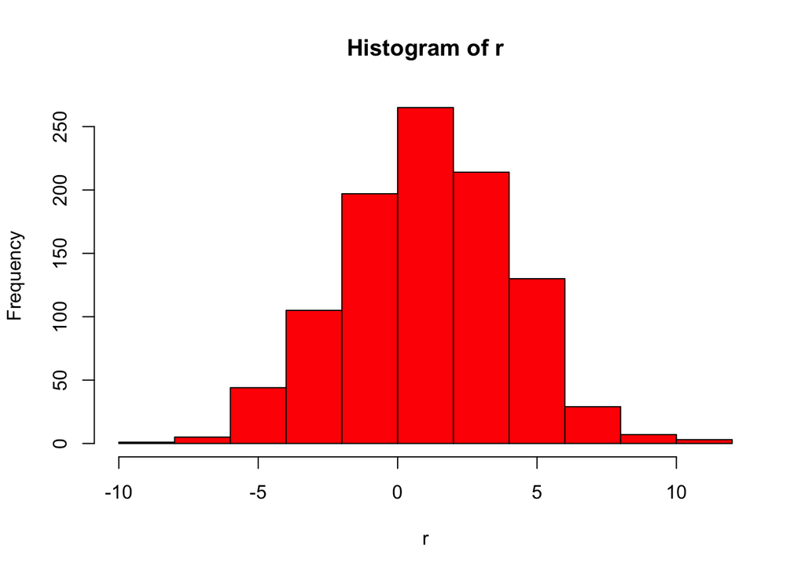

# Review:

- weighted sampling
- table(), barplot()
- distributions: densities, p-values, random number generators
- test statistics, null hypothesis and p-values
- binom.test (various versions of tests)
- function() to encapsulated pieces of code, sets of functions –> packages()
- useful misc: paste(), cat(), rgb(), sort(), ifelse()
- p.value, confidence interval and statisitical testing